# Expected Value Modeling for NBA Shot Locations

We should expect that two important drivers of the likelihood of making a shot are the shot distance and how near the closest defender is. Using data obtained from NBA.com for the 2014-2015 season, this demo explores how you can build an expected value model for shooting.

## Setup and Load Data

```python
%run ../../utils/notebook_setup.py
```

```
Adding datascience helper tools to path...
Setting up Matplotlib...
```

```
Matplotlib imported as mpl
Matplotlib.pyplot imported as plt
```

```python
%matplotlib inline
import pandas as pd
import numpy as np
import matplotlib.pyplot as plt
plt.style.use('fivethirtyeight')
pd.set_option('precision', 2)

from datascience_utils import hexbin_plot, sorted_boxplot
from datascience_topic import build_expected_shot_values_from_hexbin
```

```python
df = pd.read_csv('shot_logs_2014_15.csv.gz')
```

```python
df.head()
```

|  | GAME_ID | MATCHUP | LOCATION | W | FINAL_MARGIN | SHOT_NUMBER | PERIOD | GAME_CLOCK | SHOT_CLOCK | DRIBBLES | ... | SHOT_RESULT_BIN | PTS_MADE | CLOSE_DEF_DIST_ROUNDED | SHOT_DIST_ROUNDED | SHOT_DIST_BUCKET | DATE | PLAYER_TEAM | OPP_TEAM | HOME_TEAM | AWAY_TEAM |
| --- | --- | --- | --- | --- | --- | --- | --- | --- | --- | --- | --- | --- | --- | --- | --- | --- | --- | --- | --- | --- | --- |
| 0 | 21401229 | GSW vs. DEN | H | W | 7 | 1 | 2 | 02:05 | 10.6 | 2 | ... | 1 | 2 | 2.0 | 6.5 | 3-10 | 2015-04-15 | GSW | DEN | GSW | DEN |
| 1 | 21401212 | GSW vs. MEM | H | W | 4 | 1 | 1 | 03:55 | 6.2 | 1 | ... | 0 | 0 | 2.0 | 4.0 | 3-10 | 2015-04-13 | GSW | MEM | GSW | MEM |
| 2 | 21401212 | GSW vs. MEM | H | W | 4 | 2 | 1 | 03:54 | 5.2 | 0 | ... | 1 | 2 | 2.0 | 3.0 | 0-3 | 2015-04-13 | GSW | MEM | GSW | MEM |
| 3 | 21401212 | GSW vs. MEM | H | W | 4 | 3 | 3 | 10:02 | 16.0 | 0 | ... | 1 | 2 | 4.0 | 8.5 | 3-10 | 2015-04-13 | GSW | MEM | GSW | MEM |
| 4 | 21401212 | GSW vs. MEM | H | W | 4 | 4 | 3 | 08:26 | 1.4 | 0 | ... | 1 | 2 | 4.0 | 4.5 | 3-10 | 2015-04-13 | GSW | MEM | GSW | MEM |

5 rows × 30 columns

```python
df.info()
```

```
<class 'pandas.core.frame.DataFrame'>
RangeIndex: 203590 entries, 0 to 203589
Data columns (total 30 columns):
GAME_ID                       203590 non-null int64
MATCHUP                       203590 non-null object
LOCATION                      203590 non-null object
W                             203590 non-null object
FINAL_MARGIN                  203590 non-null int64
SHOT_NUMBER                   203590 non-null int64
PERIOD                        203590 non-null int64
GAME_CLOCK                    203590 non-null object
SHOT_CLOCK                    194997 non-null float64
DRIBBLES                      203590 non-null int64
TOUCH_TIME                    203590 non-null float64
SHOT_DIST                     203590 non-null float64
PTS_TYPE                      203590 non-null int64
SHOT_RESULT                   203590 non-null object
CLOSEST_DEFENDER              203590 non-null object
CLOSEST_DEFENDER_PLAYER_ID    203590 non-null int64
CLOSE_DEF_DIST                203590 non-null float64
FGM                           203590 non-null int64
PTS                           203590 non-null int64
playerName                    203590 non-null object
SHOT_RESULT_BIN               203590 non-null int64
PTS_MADE                      203590 non-null int64
CLOSE_DEF_DIST_ROUNDED        203590 non-null float64
SHOT_DIST_ROUNDED             203590 non-null float64
SHOT_DIST_BUCKET              203590 non-null object
DATE                          203590 non-null object
PLAYER_TEAM                   203590 non-null object
OPP_TEAM                      203590 non-null object
HOME_TEAM                     203590 non-null object
AWAY_TEAM                     203590 non-null object
dtypes: float64(6), int64(11), object(13)
memory usage: 46.6+ MB
```

## Defender Distance

There are lots of things you could do with this data but let's just jump right in with defender distance.

We use the 1ft buckets in `CLOSE_DEF_DIST_ROUNDED` to compute FG% as a function of defender distance.

After grouping, we plot the relation and... wait, why does defender distance not seem to matter!?

*Question*

- What might explain this seeming lack of relationship? Does shot type matter? Anything else?

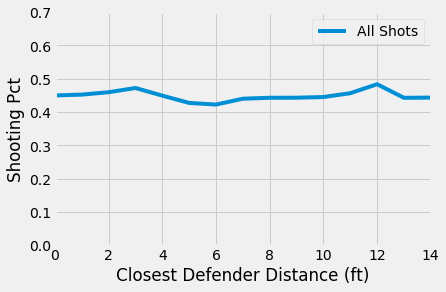

```python
result = df.groupby(['CLOSE_DEF_DIST_ROUNDED']).\
    apply(lambda g: np.mean(g.SHOT_RESULT_BIN))

fig, ax = plt.subplots()
result.loc[:14].plot(label="All Shots")
ax.set_ylabel('Shooting Pct')
ax.set_xlabel("Closest Defender Distance (ft)")
ax.set_ylim(0, .7)
ax.legend();
```

Okay, now we separate by shot type. Clearly defender distance is a big deal for 3pt shots. But it still doesn't seem that important for 2pt shots.

*Question*

- Should 2pt shooting % be immune defender distance? Why or why not? Is there something else missing?

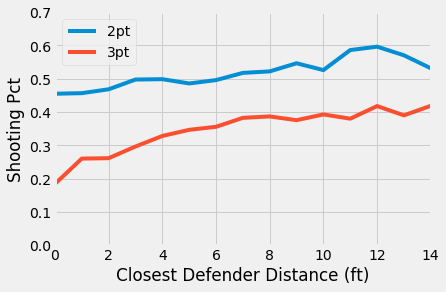

```python
result = df.groupby(['PTS_TYPE', 'CLOSE_DEF_DIST_ROUNDED']).\
    apply(lambda g: np.mean(g.SHOT_RESULT_BIN))

fig, ax = plt.subplots()
result.loc[2].loc[:14].plot(label='2pt', ax=ax)
result.loc[3].loc[:14].plot(label='3pt', ax=ax)
ax.set_ylabel('Shooting Pct')
ax.set_xlabel("Closest Defender Distance (ft)")
ax.set_ylim(0, .7)
ax.legend();
```

## Shot Distance

We can quickly visualize the variability in shot distance with a pair of histogram plots. The distance of the NBA 3pt line is not uniform but generally you see the overall pattern of shots.

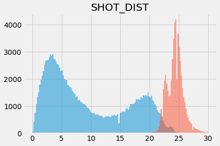

```python
nbins = 150
alpha = .5

dist_mask = df['SHOT_DIST'] <= 30
twopt = df['PTS_TYPE'] == 2
ax = df.loc[twopt & dist_mask].hist('SHOT_DIST', bins=nbins, alpha=alpha)

threept = df['PTS_TYPE'] == 3
df.loc[threept & dist_mask].hist('SHOT_DIST', bins=nbins, color='C1', alpha=alpha, ax=ax);
```

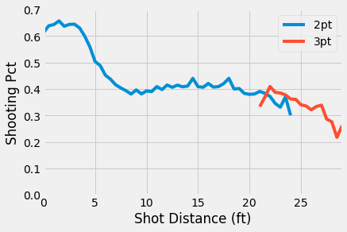

```python
result = df.groupby(['PTS_TYPE', 'SHOT_DIST_ROUNDED']).\
    apply(lambda g: np.mean(g.SHOT_RESULT_BIN)).\
    sort_index(level=0)

fig, ax = plt.subplots()
result.loc[2].loc[:24].plot(label='2pt', ax=ax)
result.loc[3].loc[21:29].plot(label='3pt', ax=ax)
ax.set_ylabel('Shooting Pct')
ax.set_xlabel("Shot Distance (ft)")
ax.set_ylim(0, .7)
ax.legend();
```

## Shot Distance and Defender Distance

Okay, we saw defender distance mattered for 3s and shot distance matters. Let's combine the two. We use the shot distance buckets in `SHOT_DIST_BUCKET` as well as the rounded defender distance to show how shooting percentage varies both in shot distance and defender distance.

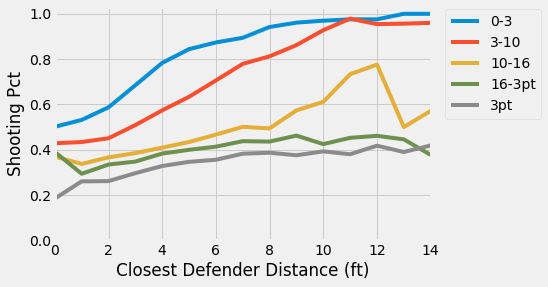

```python
result = df.groupby(['SHOT_DIST_BUCKET', 'CLOSE_DEF_DIST_ROUNDED']).\
    apply(lambda g: np.mean(g.SHOT_RESULT_BIN))

shot_buckets = ['0-3', '3-10', '10-16', '16-3pt', '3pt']
fig, ax = plt.subplots()
for bucket in shot_buckets:
    result.loc[bucket].loc[:14].plot(label=bucket, ax=ax)

ax.set_ylabel('Shooting Pct')
ax.set_xlabel("Closest Defender Distance (ft)")
ax.set_ylim(0, 1.03)
ax.legend(bbox_to_anchor=(1.02, 1.02));
```

### Hexbin Plot

We can view the relationship between the in more continuous space with a hexbin plot. A hexbin plot segments the space and all shots that lie within a hexagon will be grouped together. Then within that hexagon, we will compute the shooting percentage. We can see how regardless of shot distance, the defender distance near 0 drives down shooting percentage at that distance from the basket.

*Question*

- Why are there some spots that are extra dark or white that don't really fit with the general pattern?
- What is going on with that spike on the left side? What kind of shot has a high percentage, is near the basket, and has no defender nearby?

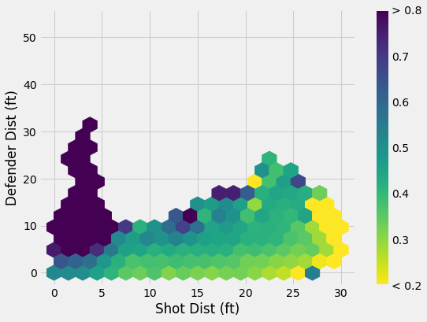

```python
hexbin_pct_plot = hexbin_plot(
    df.loc[(df.SHOT_DIST <= 30)],
    'SHOT_DIST',
    'CLOSE_DEF_DIST',
    C='SHOT_RESULT_BIN',
    collect=np.mean,
    gridsize=20,
    figsize=(8, 6),
    cmap=plt.cm.viridis_r,
    mincnt=5,
    vmin=0.2,
    vmax=0.8
)
hexbin_pct_plot.tick_params(reset=True)
hexbin_pct_plot.set_ylabel("Defender Dist (ft)")
hexbin_pct_plot.set_xlabel("Shot Dist (ft)")
cax = plt.gcf().get_axes()[1]
cax.set_yticklabels(['< 0.2', '0.3', '0.4', '0.5', '0.6', '0.7', '> 0.8']);
```

## Expected Shot Value

We can do the same hexbin plot but compute expected points. This makes more sense due to the 3pt line and represents a shooting efficiency due to the variable value of shots.

*Question*

- What does this hexbin plot say about mid/long-distance 2s as well? How bad is a closely guarded mid/long 2 point shot?

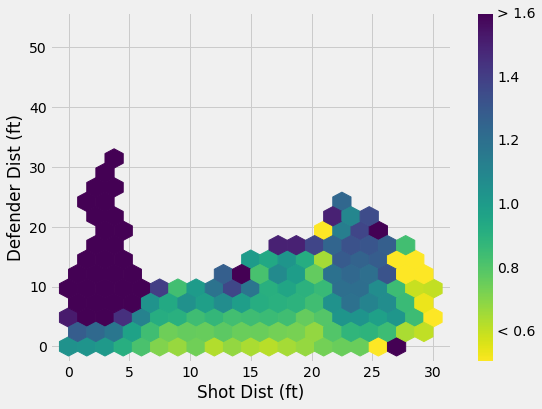

```python
hexbin_esv_plot = hexbin_plot(
    df.loc[(df.SHOT_DIST <= 30)],
    'SHOT_DIST',
    'CLOSE_DEF_DIST',
    C='PTS_MADE',
    collect=np.mean,
    gridsize=20,
    figsize=(8, 6),
    cmap=plt.cm.viridis_r,
    mincnt=5,
    vmin=0.5,
    vmax=1.6
)
hexbin_esv_plot.tick_params(reset=True)
hexbin_esv_plot.set_ylabel("Defender Dist (ft)")
hexbin_esv_plot.set_xlabel("Shot Dist (ft)")
cax = plt.gcf().get_axes()[1]
cax.set_yticklabels(['< 0.6', '0.8', '1.0', '1.2', '1.4', '> 1.6']);
```

## An Improved Shooting Metric?

Recall the Effective Field Goal Pct was given by $$ \text{eFG\%} = \frac{\mathit{FG} + .5 \cdot \mathit{3FG}}{\mathit{FGA}} = \frac{\text{Total Points (excluding FT)}}{2 \cdot \mathit{FGA}} $$

Ignoring the division by 2, our ESV computation is akin to the EFG computation: expected points scored per attempt.

Here's a metric we can build along what we've seen already in baseball: for each shot use the hexbin plot to compute the ESV.

$$ \text{eSV} = \frac{\text{Total Expected Points}}{\mathit{FGA}} $$

We can also compute the points above average for each shot as $$ \text{Points Above Average} = \text{Points Made} - \text{eSV} $$

This is actually akin to what was proposed in this [paper](http://www.sloansportsconference.com/wp-content/uploads/2014/02/2014-SSAC-Quantifying-Shot-Quality-in-the-NBA.pdf) at the Sloan conference.

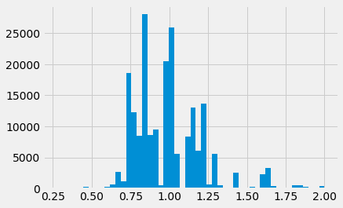

```python
# Use a helper function to get the bin (and therefore ESV) for each shot
esv = build_expected_shot_values_from_hexbin(
    df['SHOT_DIST'], df['CLOSE_DEF_DIST'], hexbin_esv_plot)
df['EXPECTED_SHOT_VALUE'] = esv
df['EXPECTED_SHOT_VALUE'].hist(bins=50);
```

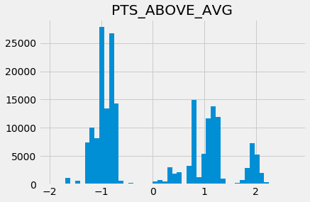

```python
df['PTS_ABOVE_AVG'] = df['PTS_MADE'] - df['EXPECTED_SHOT_VALUE']
ax = df.hist(column='PTS_ABOVE_AVG', bins=50);
```

### Player ESV

Which players are taking the highest value shots? How about the lowest?

```python
player_esv = df.groupby('playerName')['EXPECTED_SHOT_VALUE'].\
    agg({'ESVperFGA': np.mean, 'FGA': len})
```

```python
player_esv.loc[player_esv.FGA > 100].\
    sort_values('ESVperFGA', ascending=False).\
    head(20)
```

| playerName | ESVperFGA | FGA |
| --- | --- | --- |
| Tyson Chandler | 1.23 | 434.0 |
| Omer Asik | 1.22 | 411.0 |
| DeAndre Jordan | 1.22 | 523.0 |
| Joey Dorsey | 1.18 | 143.0 |
| Andre Roberson | 1.16 | 200.0 |
| Chris Andersen | 1.16 | 198.0 |
| Rudy Gobert | 1.16 | 424.0 |
| Tony Allen | 1.15 | 447.0 |
| Reggie Evans | 1.15 | 136.0 |
| Dewayne Dedmon | 1.14 | 158.0 |
| Larry Sanders | 1.13 | 170.0 |
| Maurice Harkless | 1.13 | 156.0 |
| Tyler Hansbrough | 1.13 | 163.0 |
| Tarik Black | 1.13 | 262.0 |
| Mason Plumlee | 1.12 | 451.0 |
| Alonzo Gee | 1.12 | 185.0 |
| Miles Plumlee | 1.11 | 245.0 |
| Tiago Splitter | 1.11 | 301.0 |
| Timofey Mozgov | 1.11 | 564.0 |
| Al-Farouq Aminu | 1.11 | 355.0 |

```python
player_esv.loc[player_esv.FGA > 100].\
    sort_values('ESVperFGA', ascending=True).\
    head(20)
```

| playerName | ESVperFGA | FGA |
| --- | --- | --- |
| A.J. Price | 0.87 | 137.0 |
| Kobe Bryant | 0.88 | 711.0 |
| Gary Neal | 0.88 | 502.0 |
| John Lucas III | 0.89 | 104.0 |
| Jason Smith | 0.89 | 586.0 |
| Jamal Crawford | 0.89 | 839.0 |
| Roy Hibbert | 0.89 | 708.0 |
| Dirk Nowitzki | 0.89 | 1062.0 |
| DeMar DeRozan | 0.89 | 988.0 |
| Nick Young | 0.90 | 473.0 |
| Jarrett Jack | 0.90 | 809.0 |
| Kevin Garnett | 0.90 | 299.0 |
| David West | 0.90 | 686.0 |
| Robert Sacre | 0.90 | 305.0 |
| Ben Gordon | 0.90 | 292.0 |
| Mo Williams | 0.90 | 854.0 |
| Gerald Henderson | 0.90 | 847.0 |
| Al Jefferson | 0.90 | 1007.0 |
| Andrea Bargnani | 0.90 | 360.0 |
| LaMarcus Aldridge | 0.91 | 1406.0 |

### Team ESV per 85 FGA

Which teams take the best shots? 85 FGA is about 1 game.

```python
team_esv = df.groupby('PLAYER_TEAM')['EXPECTED_SHOT_VALUE'].\
    agg({'ESVperFGA': np.mean, 'FGA': len})
team_esv['ESVper85FGA'] = 85 * team_esv['ESVperFGA']

team_esv.sort_values('ESVper85FGA', ascending=False)
```

| PLAYER_TEAM | ESVperFGA | FGA | ESVper85FGA |
| --- | --- | --- | --- |
| HOU | 1.04 | 6716.0 | 88.16 |
| ATL | 1.02 | 6651.0 | 86.74 |
| PHI | 1.02 | 6648.0 | 86.52 |
| UTA | 1.01 | 6458.0 | 86.24 |
| CLE | 1.01 | 6658.0 | 86.18 |
| PHX | 1.01 | 6979.0 | 86.08 |
| DET | 1.01 | 7007.0 | 86.04 |
| NOP | 1.01 | 6770.0 | 86.00 |
| DAL | 1.01 | 7014.0 | 85.86 |
| GSW | 1.01 | 7037.0 | 85.78 |
| SAC | 1.01 | 6545.0 | 85.53 |
| MIL | 1.00 | 6576.0 | 85.40 |
| ORL | 1.00 | 6740.0 | 85.39 |
| DEN | 1.00 | 7121.0 | 85.18 |
| MIA | 1.00 | 6203.0 | 85.11 |
| SAS | 1.00 | 6817.0 | 85.06 |
| BOS | 1.00 | 7169.0 | 84.87 |
| LAC | 0.99 | 6798.0 | 84.48 |
| MEM | 0.99 | 6686.0 | 84.41 |
| CHI | 0.99 | 6749.0 | 84.20 |
| OKC | 0.99 | 7074.0 | 84.15 |
| TOR | 0.99 | 6803.0 | 84.03 |
| POR | 0.99 | 7022.0 | 83.94 |
| WAS | 0.98 | 6751.0 | 83.53 |
| BKN | 0.97 | 6628.0 | 82.75 |
| MIN | 0.97 | 6708.0 | 82.12 |
| IND | 0.96 | 6790.0 | 81.92 |
| NYK | 0.96 | 6593.0 | 81.62 |
| LAL | 0.96 | 6974.0 | 81.54 |
| CHA | 0.95 | 6905.0 | 80.83 |

### Player Points Above Average per FGA

We can compute PAA per FGA for each player.

```python
paa = df.groupby('playerName')['PTS_ABOVE_AVG'].\
    agg({'PAAperFGA': np.mean, 'FGA': len})
```

```python
paa.loc[paa.FGA > 100].\
    sort_values('PAAperFGA', ascending=False).\
    head(20)
```

| playerName | PAAperFGA | FGA |
| --- | --- | --- |
| Kyle Korver | 0.38 | 598.0 |
| Luke Babbitt | 0.25 | 192.0 |
| Kevin Durant | 0.23 | 467.0 |
| Hedo Turkoglu | 0.23 | 188.0 |
| Stephen Curry | 0.22 | 1319.0 |
| Brandan Wright | 0.21 | 361.0 |
| JJ Redick | 0.20 | 933.0 |
| Anthony Morrow | 0.20 | 614.0 |
| DeAndre Jordan | 0.20 | 523.0 |
| Hassan Whiteside | 0.19 | 380.0 |
| Chris Paul | 0.17 | 1166.0 |
| Klay Thompson | 0.16 | 1282.0 |
| Damjan Rudez | 0.15 | 263.0 |
| Ed Davis | 0.15 | 460.0 |
| Meyers Leonard | 0.15 | 245.0 |
| James Johnson | 0.13 | 400.0 |
| Wesley Matthews | 0.13 | 751.0 |
| Alexis Ajinca | 0.12 | 327.0 |
| Dirk Nowitzki | 0.12 | 1062.0 |
| Jason Terry | 0.12 | 442.0 |

```python
paa.loc[paa.FGA > 100].\
    sort_values('PAAperFGA', ascending=False).\
    tail(20)
```

| playerName | PAAperFGA | FGA |
| --- | --- | --- |
| Ramon Sessions | -0.16 | 330.0 |
| Luc Mbah a Moute | -0.17 | 614.0 |
| Cleanthony Early | -0.17 | 213.0 |
| Tyler Ennis | -0.17 | 144.0 |
| Jimmer Fredette | -0.17 | 166.0 |
| Lou Amundson | -0.18 | 248.0 |
| Al-Farouq Aminu | -0.19 | 355.0 |
| Omer Asik | -0.19 | 411.0 |
| Markel Brown | -0.19 | 208.0 |
| Archie Goodwin | -0.20 | 199.0 |
| Jerami Grant | -0.20 | 347.0 |
| Phil Pressey | -0.22 | 174.0 |
| Elijah Millsap | -0.23 | 234.0 |
| Spencer Dinwiddie | -0.24 | 169.0 |
| Johnny O'Bryant | -0.24 | 115.0 |
| Maurice Harkless | -0.25 | 156.0 |
| Kostas Papanikolaou | -0.25 | 189.0 |
| Darius Morris | -0.27 | 105.0 |
| Gary Harris | -0.29 | 217.0 |
| Reggie Evans | -0.30 | 136.0 |

### Team Points Above Average per 85 FGA

We can compute PAA per 85 FGA for each team. 85 FGA is about 1 game.

```python
paa_team = df.groupby('PLAYER_TEAM')['PTS_ABOVE_AVG'].agg({'PAAperFGA': np.mean})
paa_team['PAAper85FGA'] = 85 * paa_team['PAAperFGA']

paa_team.sort_values('PAAper85FGA', ascending=False)
```

| PLAYER_TEAM | PAAperFGA | PAAper85FGA |
| --- | --- | --- |
| GSW | 7.68e-02 | 6.53 |
| LAC | 7.56e-02 | 6.43 |
| SAS | 3.90e-02 | 3.32 |
| ATL | 3.75e-02 | 3.19 |
| POR | 3.30e-02 | 2.80 |
| TOR | 3.12e-02 | 2.65 |
| CLE | 2.90e-02 | 2.46 |
| BKN | 2.42e-02 | 2.06 |
| DAL | 2.14e-02 | 1.82 |
| WAS | 1.77e-02 | 1.51 |
| IND | 8.69e-03 | 0.74 |
| MIA | 2.85e-03 | 0.24 |
| MIL | -2.23e-03 | -0.19 |
| OKC | -3.61e-03 | -0.31 |
| PHX | -4.59e-03 | -0.39 |
| NOP | -6.39e-03 | -0.54 |
| LAL | -7.46e-03 | -0.63 |
| CHI | -8.45e-03 | -0.72 |
| HOU | -1.07e-02 | -0.91 |
| MEM | -1.26e-02 | -1.07 |
| ORL | -1.41e-02 | -1.20 |
| NYK | -1.59e-02 | -1.35 |
| BOS | -1.78e-02 | -1.52 |
| SAC | -2.08e-02 | -1.77 |
| UTA | -2.46e-02 | -2.09 |
| MIN | -2.79e-02 | -2.37 |
| CHA | -3.50e-02 | -2.98 |
| DEN | -3.88e-02 | -3.30 |
| DET | -4.22e-02 | -3.59 |
| PHI | -9.27e-02 | -7.88 |

## Does Defender Distance Relate to Shooter Quality?

Presumably better shooters will be guarded more closely, right? To study this, let's restrict to 3pt shots.

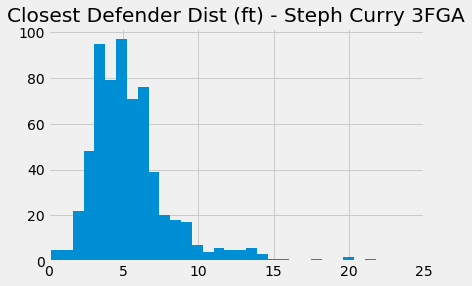

```python
steph = df.playerName == 'Stephen Curry'
fig, ax = plt.subplots()
df.loc[steph & threept].hist('CLOSE_DEF_DIST', bins=30, ax=ax)
ax.set_xlim(0, 25)
ax.set_title("Closest Defender Dist (ft) - Steph Curry 3FGA");
```

We take all players with at least 50 shots, sort them by their 3FG% (from left to right), and construct boxplots showing defender distance. If 3FG% indicates better shooters, and it should, then those players should be guarded tighter than poor shooters. We should see some kind of pattern in the plot that will reflect this hypothesis.

*Question*

- What pattern emerges from this plot? Can you think of a plausible explanation?

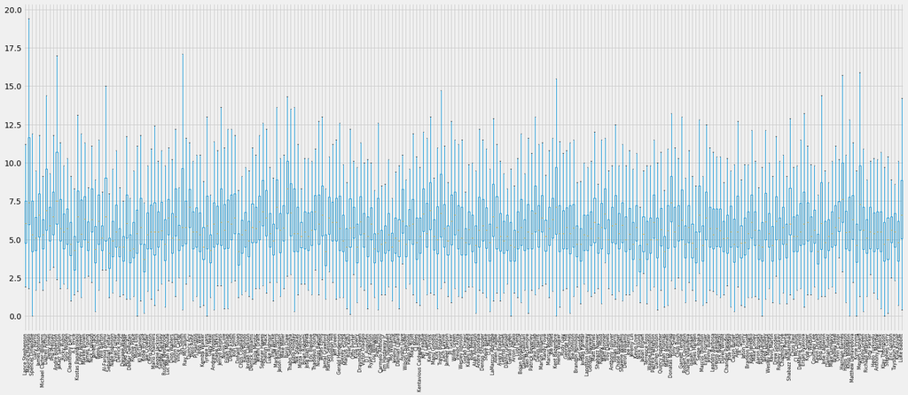

```python
num_3pt_shots = 50
by = 'playerName'
column = "CLOSE_DEF_DIST"

three_pt_shots = df.loc[threept]

by_3pt_pct = three_pt_shots.\
    groupby(by)['SHOT_RESULT_BIN'].\
    agg({'3FG%': 'mean', '3FGA': 'count'}).\
    sort_values(by='3FG%', ascending=True)
by_3pt_pct = by_3pt_pct.loc[by_3pt_pct['3FGA'] > num_3pt_shots]

player_order = by_3pt_pct.index

sorted_boxplot(three_pt_shots, by, column, player_order, figsize=(25, 10), fontsize=8)
```